# FigureYa55panCancer_violinV2

Yi Xiong, Zhougeng Xu, Ying Ge; Ying Ge, Yijing Chen

2025-5-20

## 需求描述

## requirement description

TCGA里的正常组织太少，把GTEx的正常组织加进去，用分裂小提琴图展示某个基因在TCGA肿瘤和正常组织中的表达差异。

There is too little normal tissue in TCGA, add normal tissue from GTEx and use split violin plots to show the difference in expression of a gene in TCGA tumor and normal tissue.

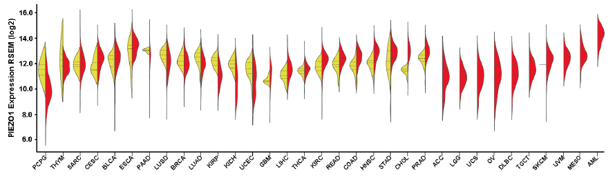

出自https://www.sciencedirect.com/science/article/pii/S0896627318308481, Supplemental material, Figure 3b

fromhttps://www.sciencedirect.com/science/article/pii/S0896627318308481, Supplemental material, Figure 3b

## 应用场景

## application scenario

适用于：

1. 对比某一基因在TCGA肿瘤组织和正常组织(TCGA的normal和GTEx)基因表达量TPM值
2. 用分裂小提琴图展示表达量数据

Applicable to:

1. compare gene expression TPM values for a gene in TCGA tumor tissue and normal tissue (TCGA’s normal and GTEx)
2. Display expression data using split violin plots

## 环境设置

## environment setting

安装需要用到的包

Install the required packages

```r
#使用国内镜像安装包
#use the domestic mirror installation package
options("repos"= c(CRAN="https://mirrors.tuna.tsinghua.edu.cn/CRAN/"))
options(BioC_mirror="http://mirrors.ustc.edu.cn/bioc/")
if (!requireNamespace("BiocManager", quietly = TRUE))
    install.packages("BiocManager")
BiocManager::install("TCGAbiolinks", version = "3.8")

install.packages("stringr")
install.packages("dplyr")
install.packages("ggplot2")
install.packages("RColorBrewer")
```

加载需要用到的包

Load the required packages

```r
library(stringr)
library(dplyr)
```

```r
library(ggplot2)
library(RColorBrewer)
source("read_part.R") # autor: 徐洲更 autor: Zhougeng Xu
Sys.setenv(LANGUAGE = "en") #显示英文报错信息 display English error messages
options(stringsAsFactors = FALSE) #禁止chr转成factor prohibit the conversion of chr to factor
```

## 参数设置

## parameter setting

```r
targetGene <- "TP53" # 想要画的目标基因 target gene you want to draw
```

## 输入文件下载

## Input file download

如果你的数据已经整理成easy_input.csv的格式，就可以跳过这步，直接进入“输入数据预处理”。

If your data has been organized into easy_input.csv format, you can skip this step and go directly to “Input data preprocessing”.

### 文件地址：

### File address:

从UCSC xenahttps://xenabrowser.net/datapages/下载经过TOIL流程统一处理的TCGA和GTEx的TPM，free of computational batch effects。

参考资料：The goal of the Toil recompute was to process ~20,000 RNA-seq samples to create a **consistent meta-analysis** of four datasets **free of computational batch effects**. https://xenabrowser.net/datapages/?hub=https://toil.xenahubs.net:443

用这套数据画出来的图跟xena的violin一致：https://xenabrowser.net/transcripts/

- TCGA Pan-Cancer (PANCAN) (39 datasets)，点击gene expression RNAseq里的TOIL RSEM tpm (n=10,535) UCSC Toil RNAseq Recompute，下载TPM：https://toil.xenahubs.net/download/tcga_RSEM_gene_tpm.gz。点击phenotype里的sample type and primary disease (n=12,804) Pan-Cancer Atlas Hub，下载phenotype：https://pancanatlas.xenahubs.net/download/TCGA_phenotype_denseDataOnlyDownload.tsv.gz
- GTEX (11 datasets)，点击gene expression RNAseq里的TOIL RSEM tpm (n=7,862) UCSC Toil RNAseq Recompute，下载TPM：https://toil.xenahubs.net/download/gtex_RSEM_gene_tpm.gz。点击phenotype里的GTEX phenotype (n=9,783) UCSC Toil RNAseq Recompute，下载phenotype：https://toil.xenahubs.net/download/GTEX_phenotype.gz
- ID和Gene symbol对应列表下载：https://toil.xenahubs.net/download/probeMap/gencode.v23.annotation.gene.probemap
- TCGA跟GTEx的组织对应关系，参照GEPIA help的Differential analysis：http://gepia.cancer-pku.cn/help.html，整理成samplepair.txt文件

**题外话：**

- 在https://xenabrowser.net/datapages/?cohort=TCGA%20Pan-Cancer%20(PANCAN)&removeHub=https%3A%2F%2Fxena.treehouse.gi.ucsc.edu%3A443这个页面，还有基于TCGA数据加工过的iCluster、Molecular subtype等宝贝等你挖掘。
- 在https://xenabrowser.net/datapages/目录下面，有TCGA的各种测序数据，下载链接有规律可循，可批量下载。

Download TPMs of TCGA and GTEx from UCSC xena https://xenabrowser.net/datapages/ that have been harmonized by the TOIL process, free of computational batch effects.

Reference: The goal of the Toil recompute was to process ~20,000 RNA-seq samples to create a **consistent meta-analysis** of four datasets **free of computational batch effects**. https://xenabrowser.net/datapages/?hub=https://toil.xenahubs.net:443

The plot drawn with this data set is consistent with xena’s violin: https://xenabrowser.net/transcripts/

- TCGA Pan-Cancer (PANCAN) (39 datasets), click on TOIL RSEM tpm (n=10,535) UCSC Toil RNAseq Recompute in gene expression RNAseq, download the TPM: https://toil.xenahubs.net/download/tcga_RSEM_gene_tpm.gz. Click on sample type and primary disease (n=12,804) Pan-Cancer Atlas Hub in phenotype, download phenotype: https://pancanatlas.xenahubs.net/download/TCGA_phenotype_denseDataOnlyDownload.tsv.gz
- GTEX (11 datasets), click on TOIL RSEM tpm (n=7,862) UCSC Toil RNAseq Recompute in gene expression RNAseq, download the TPM: https://toil.xenahubs.net/download/gtex_RSEM_gene_tpm.gz. Click on GTEX phenotype (n=9,783) UCSC Toil RNAseq Recompute in phenotype, download phenotype: https://toil.xenahubs.net/download/GTEX_phenotype.gz
- ID and Gene symbol correspondence list download: https://toil.xenahubs.net/download/probeMap/gencode.v23.annotation.gene.probemap
- The organizational correspondence between TCGA and GTEx is organized into a samplepair.txt file with reference to the Differential analysis of GEPIA help: http://gepia.cancer-pku.cn/help.html.

**Digression:**

- In https://xenabrowser.net/datapages/?cohort=TCGA%20Pan-Cancer%20(PANCAN)&removeHub=https%3A%2F%2Fxena.treehouse.gi.ucsc.edu%3A443 this page, there are also iCluster, Molecular subtype and other treasures based on processed TCGA data for you to dig out.
- Under the https://xenabrowser.net/datapages/ directory, there are various sequencing data from TCGA with regular download links for bulk downloads.

### 检查一下：你的文件夹里应该有这些输入文件：

### Check: you should have these input files in your folder:

tcga_RSEM_gene_tpm.gz

TCGA_phenotype_denseDataOnlyDownload.tsv.gz

gtex_RSEM_gene_tpm.gz

GTEX_phenotype.gz

gencode.v23.annotation.gene.probemap

samplepair.txt

## 提取目的基因在各种肿瘤和正常组织里的TPM

## Extract the TPM of the target gene in various tumors and normal tissues

### 为GTEx的sample标注组织

### Label tissue for GTEx’s sample

```r
samplepair <- read.delim("samplepair.txt",as.is = T)
gtexpair <- samplepair[,c(1,2,5)]
gtexpair
```

```
##    TCGA                                Detail          GTEx
## 1   ACC                 adrenocortical cancer Adrenal Gland
## 2  BLCA          bladder urothelial carcinoma       Bladder
## 3  BRCA             breast invasive carcinoma        Breast
## 4  CESC        cervical & endocervical cancer  Cervix Uteri
## 5  CHOL                    cholangiocarcinoma             -
## 6  COAD                  colon adenocarcinoma         Colon
## 7  DLBC         diffuse large B-cell lymphoma         Blood
## 8  ESCA                  esophageal carcinoma     Esophagus
## 9   GBM               glioblastoma multiforme         Brain
## 10 HNSC   head & neck squamous cell carcinoma             -
## 11 KICH                    kidney chromophobe        Kidney
## 12 KIRC           kidney clear cell carcinoma        Kidney
## 13 KIRP       kidney papillary cell carcinoma        Kidney
## 14 LAML                acute myeloid leukemia   Bone Marrow
```

[output cut: 19 more lines]

```r
#以TCGA的缩写为GTEx的组织命名
#name the tissues of GTEx after the abbreviation of TCGA
gtexpair$type <- paste0(gtexpair$TCGA,"_normal_GTEx")
gtexpair$type2 <-"normal"
gtextcga <- gtexpair[,c(1,3:5)] #筛掉Detail列 filter out the Detail column
colnames(gtextcga)[1:2] <- c("tissue","X_primary_site")
head(gtextcga)
```

```
##   tissue X_primary_site             type  type2
## 1    ACC  Adrenal Gland  ACC_normal_GTEx normal
## 2   BLCA        Bladder BLCA_normal_GTEx normal
## 3   BRCA         Breast BRCA_normal_GTEx normal
## 4   CESC   Cervix Uteri CESC_normal_GTEx normal
## 5   CHOL              - CHOL_normal_GTEx normal
## 6   COAD          Colon COAD_normal_GTEx normal
```

```r
#为GTEx的sample标出组织
#label tissue for GTEx's sample
gtexcase <- read.delim(file="GTEX_phenotype.gz",header=T,as.is = T)
colnames(gtexcase)[1] <- "sample"
gtexcase2tcga <- merge(gtextcga,gtexcase,by="X_primary_site")
gtextable <- gtexcase2tcga[,c(5,2:4)]
head(gtextable)
```

```
##                    sample tissue            type  type2
## 1 GTEX-QMRM-0126-SM-4R1K9    ACC ACC_normal_GTEx normal
## 2 GTEX-S32W-0126-SM-4AD61    ACC ACC_normal_GTEx normal
## 3 GTEX-ZUA1-1926-SM-5E45E    ACC ACC_normal_GTEx normal
## 4 GTEX-ZY6K-0126-SM-5SIAM    ACC ACC_normal_GTEx normal
## 5 GTEX-ZYWO-0126-SM-5GZWQ    ACC ACC_normal_GTEx normal
## 6 GTEX-XQ3S-1726-SM-4BOOD    ACC ACC_normal_GTEx normal
```

### 为TCGA的sample标注组织

### Label tissue for TCGA’s sample

```r
tissue <- gtexpair$TCGA
names(tissue) <- gtexpair$Detail

tcgacase <- read.delim(file="TCGA_phenotype_denseDataOnlyDownload.tsv.gz",header=T,as.is = T)

tcgacase$tissue <- tissue[tcgacase$X_primary_disease]
tcgacase$type <- ifelse(tcgacase$sample_type=='Solid Tissue Normal',paste(tcgacase$tissue,"normal_TCGA",sep="_"),paste(tcgacase$tissue,"tumor_TCGA",sep="_"))
tcgacase$type2 <- ifelse(tcgacase$sample_type=='Solid Tissue Normal',"normal","tumor")
tcgatable<-tcgacase[,c(1,5:7)]
head(tcgatable)
```

```
##            sample tissue            type type2
## 1 TCGA-D3-A1QA-07   SKCM SKCM_tumor_TCGA tumor
## 2 TCGA-DE-A4MD-06   THCA THCA_tumor_TCGA tumor
## 3 TCGA-J8-A3O2-06   THCA THCA_tumor_TCGA tumor
## 4 TCGA-J8-A3YH-06   THCA THCA_tumor_TCGA tumor
## 5 TCGA-EM-A2P1-06   THCA THCA_tumor_TCGA tumor
## 6 TCGA-J8-A4HW-06   THCA THCA_tumor_TCGA tumor
```

### 删除没有TPM的sample

### Delete samples without TPM

```r
headgtex <- read_part("gtex_RSEM_gene_tpm.gz", rows = 1)
gtexsample <- headgtex[1,]
gtextable2 <- gtextable[gtextable$sample %in% gtexsample,]

headtcga <- read_part("tcga_RSEM_gene_tpm.gz", rows = 1)
tcgasample <- headtcga[1,]
tcgatable2 <- tcgatable[tcgatable$sample %in% tcgasample,]

tcga_gtex<-rbind(tcgatable2,gtextable2)
```

### 比较现有数据跟GEPIA收录的sample数量

### Compare the existing data with the number of samples included in GEPIA

```r
statable<-data.frame()
for (tissuer in sort(unique(tcga_gtex$tissue))){

  tcga_gtex_tissuer<-tcga_gtex[tcga_gtex$tissue==tissuer,]

  tissuer_tumor_TCGA <- paste0(tissuer,"_tumor_TCGA")
  tissuer_normal_TCGA <- paste0(tissuer,"_normal_TCGA")
  tissuer_normal_GTEx <- paste0(tissuer,"_normal_GTEx")

  tissuerdf<-data.frame(TCGA=tissuer,
                     TCGA_new_tumor=sum(tcga_gtex_tissuer$type==tissuer_tumor_TCGA),
                     TCGA_new_normal=sum(tcga_gtex_tissuer$type==tissuer_normal_TCGA),
                     GTEx_new_num=sum(tcga_gtex_tissuer$type==tissuer_normal_GTEx),
                     stringsAsFactors=F)
  #str(tissuerdf)
  statable<-rbind(statable,tissuerdf)
}
cbind(statable, samplepair[,c(1,3:6)])
```

```
##    TCGA TCGA_new_tumor TCGA_new_normal GTEx_new_num TCGA Tumor Normal
## 1   ACC             77               0          128  ACC    77      0
## 2  BLCA            407              19            9 BLCA   404     19
## 3  BRCA           1099             113          179 BRCA  1085    112
## 4  CESC            306               3           10 CESC   306      3
## 5  CHOL             36               9            0 CHOL    36      9
## 6  COAD            290              41          308 COAD   275     41
## 7  DLBC             47               0          444 DLBC    47      0
## 8  ESCA            182              13          653 ESCA   182     13
## 9   GBM            166               5         1152  GBM   163      0
## 10 HNSC            520              44            0 HNSC   519     44
## 11 KICH             66              25           28 KICH    66     25
## 12 KIRC            531              72           28 KIRC   523     72
## 13 KIRP            289              32           28 KIRP   286     32
## 14 LAML            173               0           70 LAML   173      0
```

[output cut: 53 more lines]

前4列是现有数据，后面是GEPIA数据

The first 4 columns are existing data, followed by GEPIA data

### 找出每个基因在TPM文件中的行号

### Find the line number of each gene in the TPM file

```r
idmap <- read.delim("gencode.v23.annotation.gene.probemap",as.is=T)
head(idmap)
```

```
##                  id         gene chrom chromStart chromEnd strand
## 1 ENSG00000223972.5      DDX11L1  chr1      11869    14409      +
## 2 ENSG00000227232.5       WASH7P  chr1      14404    29570      -
## 3 ENSG00000278267.1    MIR6859-1  chr1      17369    17436      -
## 4 ENSG00000243485.3 RP11-34P13.3  chr1      29554    31109      +
## 5 ENSG00000274890.1    MIR1302-2  chr1      30366    30503      +
## 6 ENSG00000237613.2      FAM138A  chr1      34554    36081      -
```

```r
# 读取第一列, 所有行
# read the first column, all rows
tpmid2row <- read_part("gtex_RSEM_gene_tpm.gz", rows = -1, columns = 1)
tpmid2row <- tpmid2row[2:nrow(tpmid2row)]
tpmid2row <- data.frame(id = tpmid2row)
tpmid2row$rownum <- seq(1,nrow(tpmid2row))
head(tpmid2row)
```

```
##                   id rownum
## 1  ENSG00000242268.2      1
## 2  ENSG00000259041.1      2
## 3  ENSG00000270112.3      3
## 4 ENSG00000167578.16      4
## 5  ENSG00000278814.1      5
## 6  ENSG00000078237.5      6
```

```r
gene2id2row <- merge(idmap,tpmid2row,by="id")
gene2id2row <- gene2id2row[order(gene2id2row$rownum),]
head(gene2id2row)
```

```
##                       id          gene chrom chromStart  chromEnd strand rownum
## 37360  ENSG00000242268.2 RP11-368I23.2  chr3  168903366 168921996      +      1
## 46158  ENSG00000259041.1  RP11-167B3.1 chr15   98282075  98285907      +      2
## 52625  ENSG00000270112.3 RP11-742D12.2 chr18   46756487  46764408      +      3
## 12134 ENSG00000167578.16         RAB4B chr19   40778216  40796944      +      4
## 58071  ENSG00000278814.1    AC104071.1  chr4   31349786  31349874      -      5
## 1416   ENSG00000078237.5         TIGAR chr12    4321205   4354593      +      6
```

### 提取目的基因在肿瘤和正常组织的TPM

### Extract TPM of target gene in tumor and normal tissue

此处以TP53基因为例，提取它的TPM

Here we take the TP53 gene as an example to extract its TPM

```r
generownum <- gene2id2row[gene2id2row$gene==targetGene,]$rownum + 1
gtex_colnames <- read_part("gtex_RSEM_gene_tpm.gz", rows = 1)
gtex_tpm <- read_part("gtex_RSEM_gene_tpm.gz", rows = generownum)
tcga_colnames <- read_part("tcga_RSEM_gene_tpm.gz", rows = 1)
tcga_tpm <- read_part("tcga_RSEM_gene_tpm.gz", rows = generownum)

tpm <- as.numeric(c(gtex_tpm[2:length(gtex_tpm)],
                    tcga_tpm[2:length(tcga_tpm)] ))
names(tpm) <- c(gtex_colnames[2:length(gtex_colnames)],
                    tcga_colnames[2:length(tcga_colnames)] )

tcga_gtex$tpm <- tpm[tcga_gtex$sample]

#按组织排序
#sort by tissue
tcga_gtex <- arrange(tcga_gtex,tissue)
write.csv(tcga_gtex[,c(2,4,5)],"easy_input.csv", quote = F)
```

## 输入数据预处理

## Input data preprocessing

easy_input.csv：第1列tissue是组织（分组），第2列type2是肿瘤/正常组织（左右分组），第3列tpm是TPM值。

有些组织没有normal，需要识别出来单独画。

easy_input.csv: column 1 tissue is tissue (grouping), column 2 type2 is tumor/normal tissue (left/right grouping), column 3 tpm is TPM value.

Some tissues do not have normal and need to be identified and drawn separately.

```r
tcga_gtex <- read.csv("easy_input.csv", row.names = 1, header = T, as.is = F)
head(tcga_gtex)
```

```
##       tissue type2    tpm
## 11146    ACC tumor 4.1327
## 11147    ACC tumor 4.9519
## 11148    ACC tumor 3.0619
## 11149    ACC tumor 2.7051
## 11150    ACC tumor 1.9749
## 11151    ACC tumor 3.1079
```

```r
tumorlist <- unique(tcga_gtex[tcga_gtex$type2=="tumor",]$tissue)
normallist <- unique(tcga_gtex[tcga_gtex$type2=="normal",]$tissue)
withoutNormal <- setdiff(tumorlist, normallist)
```

MESO和UVM没有normal

MESO and UVM do not have normal

```r
tcga_gtex$type2 <- factor(tcga_gtex$type2,levels=c("tumor","normal"))
tcga_gtex_withNormal <- tcga_gtex[!(tcga_gtex$tissue %in% withoutNormal),]
tcga_gtex_MESO <- tcga_gtex[tcga_gtex$tissue=="MESO",]
tcga_gtex_UVM <- tcga_gtex[tcga_gtex$tissue=="UVM",]
```

## 开始画图

## Start drawing

要用到SplitViolin的图层和函数，保存在GeomSplitViolin.R文件中，位于当前文件夹。

To use the layers and functions of SplitViolin, save them in the GeomSplitViolin.R file, located in the current folder.

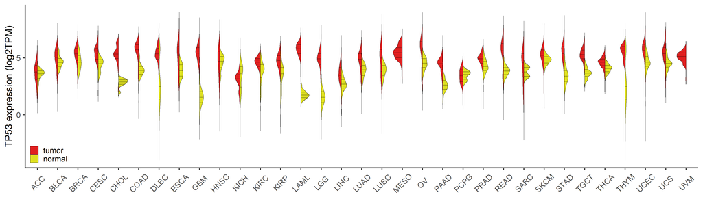

```r
source("GeomSplitViolin.R") #位于当前文件夹 located in the current folder

p <- ggplot(tcga_gtex_withNormal, aes(x = tissue, y = tpm, fill = type2)) + #x对应肿瘤的类型，y对应表达量，fill填充对应组织的类型 x corresponds to the type of tumor, y corresponds to the amount of expression, and fill corresponds to the type of tissue
  geom_split_violin(draw_quantiles = c(0.25, 0.5, 0.75), #画4分位线 draw a quartile line
                    trim = F, #是否修剪小提琴图的密度曲线 whether to trim the density curve of the violin plot
                    linetype = "solid", #周围线的轮廓 outline of the perimeter line
                    color = "black", #周围线颜色 color of the perimeter line
                    size = 0.2,
                    na.rm = T,
                    position ="identity")+ #周围线粗细 thickness of the perimeter line
  ylab(paste0(targetGene, " expression (log2TPM)")) + xlab("") +
  ylim(-4,9) +
  scale_fill_manual(values = c("#DF2020", "#DDDF21"))+
  theme_set(theme_set(theme_classic(base_size=20)))+
  theme(axis.text.x = element_text(angle = 45, hjust = .5, vjust = .5)) + #x轴label倾斜45度 x-axis label is tilted 45 degrees

  guides(fill = guide_legend(title = NULL)) +
  theme(legend.background = element_blank(), #移除整体边框 remove overall border
        #图例的左下角置于绘图区域的左下角
        #the lower left corner of the legend is placed in the lower left corner of the drawing area
        legend.position=c(0,0),legend.justification = c(0,0))
p + geom_split_violin(data = tcga_gtex_MESO,
                       mapping = aes(x = tissue, y = tpm, fill = type2),
                       draw_quantiles = c(0.25, 0.5, 0.75), #画4分位线 draw a quartile line
                    trim = F, #是否修剪小提琴图的密度曲线 whether to trim the density curve of the violin plot
                    linetype = "solid", #周围线的轮廓 outline of the perimeter line
                    color = "black", #周围线颜色 color of the perimeter line
                    size = 0.2,
                    na.rm = T,
                    position ="identity") +
  geom_split_violin(data = tcga_gtex_UVM,
                       mapping = aes(x = tissue, y = tpm, fill = type2),
                       draw_quantiles = c(0.25, 0.5, 0.75), #画4分位线 draw a quartile line
                    trim = F, #是否修剪小提琴图的密度曲线 whether to trim the density curve of the violin plot
                    linetype = "solid", #周围线的轮廓 outline of the perimeter line
                    color = "black", #周围线颜色 color of the perimeter line
                    size = 0.2,
                    na.rm = T,
                    position ="identity") +
  scale_x_discrete(limits = levels(tcga_gtex$tissue))
```

```r
ggsave(paste0(targetGene, "expression.pdf"),width = 20, height = 6)
```